# Data Exploration and Pre-processing - Data wrangling -

**Project objective:**  
Multi Class prediction of water pumps status (Functional, Non Functional, Functional Needs Repair) using the provided features and labels.  
Accurate predection of which pump or waterpoint will fail will enable proactive maintenance and increase water availablity and imporove the overall health and hygine in the areas serviced by the waterpoints.  
please note that error logs are kept so you can have a better understanding of my actions and decesions throgh the pipeline

## Importing required packages

```python
### importing required packages
#setup package auto reload to minimize risks of running outdated external modules
%load_ext autoreload
%autoreload 2


# local file links
from IPython.display import FileLink, FileLinks


# panda for data peocession
import pandas as pd
# setup Pandas
pd.set_option('display.width', 600)

# numpy for data wrangling
import numpy as np

# seaborn for data visulization
# why I use seaborn with matplotlib?
# https://analyticsindiamag.com/comparing-python-data-visualization-tools-matplotlib-vs-seaborn/#:~:text=Matplotlib%3A%20Matplotlib%20is%20mainly%20deployed,has%20easily%20interesting%20default%20themes.
import matplotlib as mpl
import matplotlib.pyplot as plt
%matplotlib inline

import seaborn as sns
# setup seaborn
sns.set_style("whitegrid")

#ipython disply for better dataframe prints
from IPython.display import display, HTML


#pprint for better look print statements
import pprint


# pandas profiling package for a deep and quick look at features
from pandas_profiling import ProfileReport
```

```
The autoreload extension is already loaded. To reload it, use:
  %reload_ext autoreload
```

## Loading project data

```python
# loading csv data files into pandas data frames


# A- why my first choice is 'c' vs 'python' for data parser engine?
# https://stackoverflow.com/questions/52774459/engines-in-python-pandas-read-csv

# B- using infer_datetime_format to convert string date feature to date datatype on loading (if detected by parser)

# C- verbose allows to early detect data or memory issues
# we can see below that one of the collumns have mixed datatypes

# D- used the id collumn as index for both dataframes for better performance when joined back

df_features = pd.read_csv('../data/data.csv',engine = 'c', infer_datetime_format = True, verbose = True, index_col='id', encoding = 'iso-8859-1')
df_labels = pd.read_csv('../data/labels.csv',engine = 'c', infer_datetime_format = True, verbose = True, index_col='id', encoding = 'iso-8859-1')
print("Features shape: " + str(df_features.shape))
print("Labels shape: "+ str(df_labels.shape))

#renaming id to index
df_labels.index.names = ['index']
df_features.index.names = ['index']
```

```
Tokenization took: 73.64 ms
Type conversion took: 59.63 ms
Parser memory cleanup took: 0.01 ms
Tokenization took: 43.54 ms
Type conversion took: 56.30 ms
Parser memory cleanup took: 0.01 ms
Tokenization took: 45.24 ms
Type conversion took: 63.93 ms
Parser memory cleanup took: 0.01 ms
Tokenization took: 28.34 ms
Type conversion took: 45.21 ms
Parser memory cleanup took: 0.01 ms
Tokenization took: 10.49 ms
Type conversion took: 18.19 ms
Parser memory cleanup took: 0.01 ms
Features shape: (59401, 39)
Labels shape: (59400, 1)
```

### First look at target and features

> Note: (39) features with (59401) rows > labels (59400) rows by 1

```python
#looking at the data we loaded - labels
print (df_labels.info())
display(HTML(df_labels[:10].to_html()))
```

```
<class 'pandas.core.frame.DataFrame'>
Index: 59400 entries, 69572 to 26348
Data columns (total 1 columns):
 #   Column        Non-Null Count  Dtype
---  ------        --------------  -----
 0   status_group  59400 non-null  object
dtypes: object(1)
memory usage: 928.1+ KB
None
```

| index | status_group |
| --- | --- |
| 69572 | functional |
| 8776 | functional |
| 34310 | functional |
| 67743 | non functional |
| 19728 | functional |
| 9944 | functional |
| 19816 | non functional |
| 54551 | non functional |
| 53934 | non functional |
| 46144 | functional |

> Note: index or id field is an object

```python
#looking at the data we loaded - feaures
print (df_features.info())
display(HTML(df_features[:10].to_html()))
```

```
<class 'pandas.core.frame.DataFrame'>
Int64Index: 59401 entries, 69572 to 26348
Data columns (total 39 columns):
 #   Column                 Non-Null Count  Dtype
---  ------                 --------------  -----
 0   amount_tsh             59401 non-null  object
 1   date_recorded          59401 non-null  object
 2   funder                 55766 non-null  object
 3   gps_height             59400 non-null  float64
 4   installer              55746 non-null  object
 5   longitude              59401 non-null  float64
 6   latitude               59401 non-null  float64
 7   wpt_name               59401 non-null  object
 8   num_private            59401 non-null  int64
 9   basin                  59401 non-null  object
```

[output cut: 32 more lines]

| index | amount_tsh | date_recorded | funder | gps_height | installer | longitude | latitude | wpt_name | num_private | basin | subvillage | region | region_code | district_code | lga | ward | population | public_meeting | recorded_by | scheme_management | scheme_name | permit | construction_year | extraction_type | extraction_type_group | extraction_type_class | management | management_group | payment | … |
| --- | --- | --- | --- | --- | --- | --- | --- | --- | --- | --- | --- | --- | --- | --- | --- | --- | --- | --- | --- | --- | --- | --- | --- | --- | --- | --- | --- | --- | --- | --- |
| 69572 | 6000 | 3/14/11 | Roman | 1390.0 | Roman | 34.938093 | -9.856322 | none | 0 | Lake Nyasa | Mnyusi B | Iringa | 11 | 5 | Ludewa | Mundindi | 109 | True | GeoData Consultants Ltd | VWC | Roman | False | 1999 | gravity | gravity | gravity | vwc | user-group | pay annually | … |
| 8776 | 0 | 3/6/13 | Grumeti | 1399.0 | GRUMETI | 34.698766 | -2.147466 | Zahanati | 0 | Lake Victoria | Nyamara | Mara | 20 | 2 | Serengeti | Natta | 280 | NaN | GeoData Consultants Ltd | Other | NaN | True | 2010 | gravity | gravity | gravity | wug | user-group | never pay | … |
| 34310 | 25 | 2/25/13 | Lottery Club | 686.0 | World vision | 37.460664 | -3.821329 | Kwa Mahundi | 0 | Pangani | Majengo | Manyara | 21 | 4 | Simanjiro | Ngorika | 250 | True | GeoData Consultants Ltd | VWC | Nyumba ya mungu pipe scheme | True | 2009 | gravity | gravity | gravity | vwc | user-group | pay per bucket | … |
| 67743 | 0 | 1/28/13 | Unicef | 263.0 | UNICEF | 38.486161 | -11.155298 | Zahanati Ya Nanyumbu | 0 | Ruvuma / Southern Coast | Mahakamani | Mtwara | 90 | 63 | Nanyumbu | Nanyumbu | 58 | True | GeoData Consultants Ltd | VWC | NaN | True | 1986 | submersible | submersible | submersible | vwc | user-group | never pay | … |
| 19728 | 0 | 7/13/11 | Action In A | 0.0 | Artisan | 31.130847 | -1.825359 | Shuleni | 0 | Lake Victoria | Kyanyamisa | Kagera | 18 | 1 | Karagwe | Nyakasimbi | 0 | True | GeoData Consultants Ltd | NaN | NaN | True | 0 | gravity | gravity | gravity | other | other | never pay | … |
| 9944 | 20 | 3/13/11 | Mkinga Distric Coun | 0.0 | DWE | 39.172796 | -4.765587 | Tajiri | 0 | Pangani | Moa/Mwereme | Tanga | 4 | 8 | Mkinga | Moa | 1 | True | GeoData Consultants Ltd | VWC | Zingibali | True | 2009 | submersible | submersible | submersible | vwc | user-group | pay per bucket | … |
| 19816 | 0 | 10/1/12 | Dwsp | 0.0 | DWSP | 33.362410 | -3.766365 | Kwa Ngomho | 0 | Internal | Ishinabulandi | Shinyanga | 17 | 3 | Shinyanga Rural | Samuye | 0 | True | GeoData Consultants Ltd | VWC | NaN | True | 0 | swn 80 | swn 80 | handpump | vwc | user-group | never pay | … |
| 54551 | 0 | 10/9/12 | Rwssp | 0.0 | DWE | 32.620617 | -4.226198 | Tushirikiane | 0 | Lake Tanganyika | Nyawishi Center | Shinyanga | 17 | 3 | Kahama | Chambo | 0 | True | GeoData Consultants Ltd | NaN | NaN | True | 0 | nira/tanira | nira/tanira | handpump | wug | user-group | unknown | … |
| 53934 | 0 | 11/3/12 | Wateraid | 0.0 | Water Aid | 32.711100 | -5.146712 | Kwa Ramadhan Musa | 0 | Lake Tanganyika | Imalauduki | Tabora | 14 | 6 | Tabora Urban | Itetemia | 0 | True | GeoData Consultants Ltd | VWC | NaN | True | 0 | india mark ii | india mark ii | handpump | vwc | user-group | never pay | … |
| 46144 | 0 | 8/3/11 | Isingiro Ho | 0.0 | Artisan | 30.626991 | -1.257051 | Kwapeto | 0 | Lake Victoria | Mkonomre | Kagera | 18 | 1 | Karagwe | Kaisho | 0 | True | GeoData Consultants Ltd | NaN | NaN | True | 0 | nira/tanira | nira/tanira | handpump | vwc | user-group | never pay | … |

**Initial Notes:**

- date_recoreded and amount_tsh parsed as objects - those need a fix
- 4 numarical /2 temporal/ 10 geographical / 23 categorical features = 39 feature in total

## Closer look at labels dataset

> how many target classes?

```python
print(df_labels['status_group'].nunique())
```

```
4
```

> what are the unique classes?

```python
print (df_labels['status_group'].unique())
```

```
['functional' 'non functional' 'functional needs repair' 'nonfunctional']
```

> how many empty/nulls rows in target/labels?

```python
#listing label data type and null counts if exists
print(df_labels.info())
```

```
<class 'pandas.core.frame.DataFrame'>
Index: 59400 entries, 69572 to 26348
Data columns (total 1 columns):
 #   Column        Non-Null Count  Dtype
---  ------        --------------  -----
 0   status_group  59400 non-null  object
dtypes: object(1)
memory usage: 928.1+ KB
None
```

```python
print(df_features.index.nunique())
print(df_features.index.isnull().sum())
```

```
59400
0
```

### Labels data set cleaning round 1- fix join issue

**Notes:**

- no empty or null labels
- 3 clasess
- one row with wrong data entry- to be fixed maually
- index/id column will need a fix to be converted to int64index to enable the join of labels and features

> A- Lets update the faulty row.

```python
df_labels.loc[df_labels.status_group == "nonfunctional", "status_group"] = "non functional"
```

> B- Lets fix the index datatype

```python
# temporary getting back the id field form the index to ease casting
df_labels['id_temp']= list(df_labels.index)
df_labels['id_temp']= df_labels['id_temp'].astype('int64')

#check if the fix worked
print(df_labels.info())
print(type(df_labels.index))
print(type(df_features.index))
```

[output not shown]

> error!! ValueError: invalid literal for int() with base 10: '135!1'

> look if the row is a duplicate of '13511' ?

```python
filterA = df_labels["id_temp"]=='135!1'
filterB = df_labels["id_temp"]=='13511'

# filtering data
error_rows = df_labels.where(filterA | filterB , inplace = False)
# display the rows for invistgation
display(HTML(error_rows.dropna(subset=['id_temp']).to_html()))
```

| index | status_group | id_temp |
| --- | --- | --- |
| 135!1 | non functional | 135!1 |
| 13511 | functional | 13511 |

> Not A duplicate.

> look at there features as well for final decesion

```python
# temporary getting back the id field form the index for enable filtring
df_features['id_temp']= list(df_features.index)

# making boolean series for the filter
filterC = df_features['id_temp']==13511



# filtering data
error_rows = df_features.where(filterC , inplace = False)
# display the rows for invistgation
display(HTML(error_rows.dropna(subset=['id_temp']).to_html()))
```

| index | amount_tsh | date_recorded | funder | gps_height | installer | longitude | latitude | wpt_name | num_private | basin | subvillage | region | region_code | district_code | lga | ward | population | public_meeting | recorded_by | scheme_management | scheme_name | permit | construction_year | extraction_type | extraction_type_group | extraction_type_class | management | management_group | payment | … |
| --- | --- | --- | --- | --- | --- | --- | --- | --- | --- | --- | --- | --- | --- | --- | --- | --- | --- | --- | --- | --- | --- | --- | --- | --- | --- | --- | --- | --- | --- | --- |
| 13511 | 0 | 2/27/11 | Shipo | 1796.0 | Shipo | 34.847781 | -9.124109 | Ibumila Dispensary | 0.0 | Rufiji | Muungano | Iringa | 11.0 | 4.0 | Njombe | Igongolo | 300.0 | True | GeoData Consultants Ltd | VWC | NaN | False | 2007.0 | other - rope pump | rope pump | rope pump | vwc | user-group | never pay | … |

```python
#drop temp id column
df_features.drop(columns=['id_temp'], inplace=True)
```

> decesion is to remove the faulty id entry from labels and reindex the dataframe

```python
# removing faulty row
df_labels.drop("135!1", axis=0, inplace=True)
```

```python
# now casting index field to int64 to match features dataframe index to ease merging/joining
df_labels['id_temp']= list(df_labels.index)
df_labels['id_temp']= df_labels['id_temp'].astype('int64')
```

```python
# re-indexing
#df_labels.rename(columns={"id_temp": "id_old"}, inplace=True)
df_labels.set_index("id_temp", inplace=True)
#renaming the index
df_labels.index.names = ['index']
```

```python
#check if the fix worked
print(df_labels.info())
print(type(df_labels.index))
print(type(df_features.index))
```

```
<class 'pandas.core.frame.DataFrame'>
Int64Index: 59399 entries, 69572 to 26348
Data columns (total 1 columns):
 #   Column        Non-Null Count  Dtype
---  ------        --------------  -----
 0   status_group  59399 non-null  object
dtypes: object(1)
memory usage: 928.1+ KB
None
<class 'pandas.core.indexes.numeric.Int64Index'>
<class 'pandas.core.indexes.numeric.Int64Index'>
```

### Checking classes balance

> what is the class balance?

```
functional                 32259
non functional             22824
functional needs repair     4316
Name: status_group, dtype: int64



functional                 0.543090
non functional             0.384249
functional needs repair    0.072661
Name: status_group, dtype: float64
```

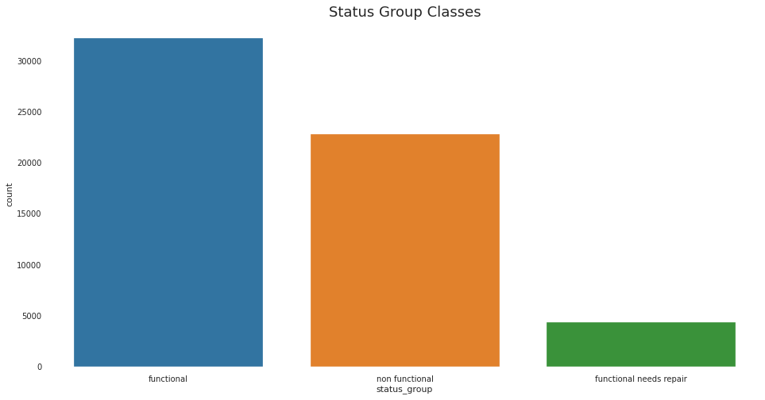

```python
# data points counts of each class
print (df_labels['status_group'].value_counts())
print ("\n \n")

# data points percentage of each class
print (df_labels['status_group'].value_counts()/len(df_labels['status_group']))
# bar plot of classes
plt.figure(figsize=(16,8))
plt.title("Status Group Classes",fontsize=18)
sns.countplot(df_labels['status_group'])
```

## Closer look at features dataset

```python
#looking at the data features
pp = pprint.PrettyPrinter(width=110, compact=True)
pp.pprint(list(df_features.columns))
```

```
['amount_tsh', 'date_recorded', 'funder', 'gps_height', 'installer', 'longitude', 'latitude', 'wpt_name',
 'num_private', 'basin', 'subvillage', 'region', 'region_code', 'district_code', 'lga', 'ward', 'population',
 'public_meeting', 'recorded_by', 'scheme_management', 'scheme_name', 'permit', 'construction_year',
 'extraction_type', 'extraction_type_group', 'extraction_type_class', 'management', 'management_group',
 'payment', 'payment_type', 'water_quality', 'quality_group', 'quantity', 'quantity_group', 'source',
 'source_type', 'source_class', 'waterpoint_type', 'waterpoint_type_group']
```

```python
#listing features data types and null count
df_features.info()
display(HTML(df_features[:10].to_html()))
```

```
<class 'pandas.core.frame.DataFrame'>
Int64Index: 59401 entries, 69572 to 26348
Data columns (total 39 columns):
 #   Column                 Non-Null Count  Dtype
---  ------                 --------------  -----
 0   amount_tsh             59401 non-null  object
 1   date_recorded          59401 non-null  object
 2   funder                 55766 non-null  object
 3   gps_height             59400 non-null  float64
 4   installer              55746 non-null  object
 5   longitude              59401 non-null  float64
 6   latitude               59401 non-null  float64
 7   wpt_name               59401 non-null  object
 8   num_private            59401 non-null  int64
 9   basin                  59401 non-null  object
```

[output cut: 31 more lines]

| index | amount_tsh | date_recorded | funder | gps_height | installer | longitude | latitude | wpt_name | num_private | basin | subvillage | region | region_code | district_code | lga | ward | population | public_meeting | recorded_by | scheme_management | scheme_name | permit | construction_year | extraction_type | extraction_type_group | extraction_type_class | management | management_group | payment | … |
| --- | --- | --- | --- | --- | --- | --- | --- | --- | --- | --- | --- | --- | --- | --- | --- | --- | --- | --- | --- | --- | --- | --- | --- | --- | --- | --- | --- | --- | --- | --- |
| 69572 | 6000 | 3/14/11 | Roman | 1390.0 | Roman | 34.938093 | -9.856322 | none | 0 | Lake Nyasa | Mnyusi B | Iringa | 11 | 5 | Ludewa | Mundindi | 109 | True | GeoData Consultants Ltd | VWC | Roman | False | 1999 | gravity | gravity | gravity | vwc | user-group | pay annually | … |
| 8776 | 0 | 3/6/13 | Grumeti | 1399.0 | GRUMETI | 34.698766 | -2.147466 | Zahanati | 0 | Lake Victoria | Nyamara | Mara | 20 | 2 | Serengeti | Natta | 280 | NaN | GeoData Consultants Ltd | Other | NaN | True | 2010 | gravity | gravity | gravity | wug | user-group | never pay | … |
| 34310 | 25 | 2/25/13 | Lottery Club | 686.0 | World vision | 37.460664 | -3.821329 | Kwa Mahundi | 0 | Pangani | Majengo | Manyara | 21 | 4 | Simanjiro | Ngorika | 250 | True | GeoData Consultants Ltd | VWC | Nyumba ya mungu pipe scheme | True | 2009 | gravity | gravity | gravity | vwc | user-group | pay per bucket | … |
| 67743 | 0 | 1/28/13 | Unicef | 263.0 | UNICEF | 38.486161 | -11.155298 | Zahanati Ya Nanyumbu | 0 | Ruvuma / Southern Coast | Mahakamani | Mtwara | 90 | 63 | Nanyumbu | Nanyumbu | 58 | True | GeoData Consultants Ltd | VWC | NaN | True | 1986 | submersible | submersible | submersible | vwc | user-group | never pay | … |
| 19728 | 0 | 7/13/11 | Action In A | 0.0 | Artisan | 31.130847 | -1.825359 | Shuleni | 0 | Lake Victoria | Kyanyamisa | Kagera | 18 | 1 | Karagwe | Nyakasimbi | 0 | True | GeoData Consultants Ltd | NaN | NaN | True | 0 | gravity | gravity | gravity | other | other | never pay | … |
| 9944 | 20 | 3/13/11 | Mkinga Distric Coun | 0.0 | DWE | 39.172796 | -4.765587 | Tajiri | 0 | Pangani | Moa/Mwereme | Tanga | 4 | 8 | Mkinga | Moa | 1 | True | GeoData Consultants Ltd | VWC | Zingibali | True | 2009 | submersible | submersible | submersible | vwc | user-group | pay per bucket | … |
| 19816 | 0 | 10/1/12 | Dwsp | 0.0 | DWSP | 33.362410 | -3.766365 | Kwa Ngomho | 0 | Internal | Ishinabulandi | Shinyanga | 17 | 3 | Shinyanga Rural | Samuye | 0 | True | GeoData Consultants Ltd | VWC | NaN | True | 0 | swn 80 | swn 80 | handpump | vwc | user-group | never pay | … |
| 54551 | 0 | 10/9/12 | Rwssp | 0.0 | DWE | 32.620617 | -4.226198 | Tushirikiane | 0 | Lake Tanganyika | Nyawishi Center | Shinyanga | 17 | 3 | Kahama | Chambo | 0 | True | GeoData Consultants Ltd | NaN | NaN | True | 0 | nira/tanira | nira/tanira | handpump | wug | user-group | unknown | … |
| 53934 | 0 | 11/3/12 | Wateraid | 0.0 | Water Aid | 32.711100 | -5.146712 | Kwa Ramadhan Musa | 0 | Lake Tanganyika | Imalauduki | Tabora | 14 | 6 | Tabora Urban | Itetemia | 0 | True | GeoData Consultants Ltd | VWC | NaN | True | 0 | india mark ii | india mark ii | handpump | vwc | user-group | never pay | … |
| 46144 | 0 | 8/3/11 | Isingiro Ho | 0.0 | Artisan | 30.626991 | -1.257051 | Kwapeto | 0 | Lake Victoria | Mkonomre | Kagera | 18 | 1 | Karagwe | Kaisho | 0 | True | GeoData Consultants Ltd | NaN | NaN | True | 0 | nira/tanira | nira/tanira | handpump | vwc | user-group | never pay | … |

### Features data set cleaning round 1 - fix parsing errors for [amount_tsh and date_recorded]

> A- Lets start with the amount_tsh parsing error fix

```python
# casting amount_tsh field to float64
df_features['amount_tsh']= df_features['amount_tsh'].astype('float64')
```

[output not shown]

> ValueError: could not convert string to float: 'zero'

> Lets debug and fix that faulty entry!

```python
# making boolean series for the filter
filterD = df_features['amount_tsh']=='zero'
filterE = df_features['amount_tsh']=='Zero'


# filtering data
error_rows = df_features.where(filterD | filterE , inplace = False)
# display the rows for invistgation
display(HTML(error_rows.dropna(subset=['amount_tsh']).to_html()))
```

| index | amount_tsh | date_recorded | funder | gps_height | installer | longitude | latitude | wpt_name | num_private | basin | subvillage | region | region_code | district_code | lga | ward | population | public_meeting | recorded_by | scheme_management | scheme_name | permit | construction_year | extraction_type | extraction_type_group | extraction_type_class | management | management_group | payment | … |
| --- | --- | --- | --- | --- | --- | --- | --- | --- | --- | --- | --- | --- | --- | --- | --- | --- | --- | --- | --- | --- | --- | --- | --- | --- | --- | --- | --- | --- | --- | --- |
| 39870 | zero | 3/28/11 | Danida | 0.0 | DANIDA | 33.342778 | -8.984626 | Aron Nswila | 0.0 | Lake Rukwa | Nsenga | Mbeya | 12.0 | 2.0 | Mbeya Rural | Iwindi | 0.0 | True | GeoData Consultants Ltd | VWC | NaN | True | 0.0 | gravity | gravity | gravity | wug | user-group | pay when scheme fails | … |

```python
# change zero to 0
df_features.loc[df_features['amount_tsh'] == "zero", "amount_tsh"] = 0
```

```python
# lets cast again
# casting amount_tsh field to float64
df_features['amount_tsh']= df_features['amount_tsh'].astype('float64')
# chech if worked?
print (df_features['amount_tsh'].dtype)
```

```
float64
```

> B- Lets get the date_recorded parsing error fixed!

```python
# casting date_recorded field to datetime64
df_features['date_recorded']= df_features['date_recorded'].astype('datetime64')
# chech if worked?
print (df_features['date_recorded'].dtype)
df_features.head(2)
```

```
datetime64[ns]
```

| index | amount_tsh | date_recorded | funder | gps_height | installer | longitude | latitude | wpt_name | num_private | basin | ... | payment_type | water_quality | quality_group | quantity | quantity_group | source | source_type | source_class | waterpoint_type | waterpoint_type_group |
| --- | --- | --- | --- | --- | --- | --- | --- | --- | --- | --- | --- | --- | --- | --- | --- | --- | --- | --- | --- | --- | --- |
| 69572 | 6000.0 | 2011-03-14 | Roman | 1390.0 | Roman | 34.938093 | -9.856322 | none | 0 | Lake Nyasa | ... | annually | soft | good | enough | enough | spring | spring | groundwater | communal standpipe | communal standpipe |
| 8776 | 0.0 | 2013-03-06 | Grumeti | 1399.0 | GRUMETI | 34.698766 | -2.147466 | Zahanati | 0 | Lake Victoria | ... | never pay | soft | good | insufficient | insufficient | rainwater harvesting | rainwater harvesting | surface | communal standpipe | communal standpipe |

2 rows × 39 columns

## Intinsive dataset profiling

this includes the following tasks:

- merging features and labels
- exploratory analysis and pairwise plots (interactions)
- feature visulization
- finiding missing values
- finiding currupt entries
- feature correlation analysis - pearson correlation - 90% threshould
- conclusions and actions towards the above findings

### Merging features and labels

**Notes:**

- using join instead of merge as it work better when joinin on dataframe indexes
- id column is in different data types for each dataframe - this is fixed in previouse steps

```python
# inner joining on index OR id
df_initial = df_features.join(df_labels, on='index', how= 'inner')
```

### Dataset profiling using pandas_profiling Package

```python
ds_profile = ProfileReport(df_initial, title='Dataset Profiling Report'
                        , explorative=True, html={"style":{"full_width": True}})
```

```python
ds_profile.to_notebook_iframe()
```

[interactive chart not shown]

### Dataset profiling findings

**Obsevations on the above dataset profiling report:**

- 4 numarical /2 temporal/ 10 geographical / 23 categorical features = 39 feature in total
- data integrity issues: id: 70713, 7464 have 2 entries basin: Lake Victoriia to Lake Victoria subvillage: M,I,1 dosen't look correct population: negative 200 is not accepted 0 and 1 are doubtful recorded_by: constant = GeoData Consultants LTD (execlude from modeling) payment_type: 1 datapoint have "bitcoin" which looks incorrect source_type : 1 datapoint have "guinness" which is incorrect
- missing values : amount_tsh = 70.1% zeros funder = 6.1%+ 1.3% zeros installer = 6.2% + 1.3% zeros longitude = 3.1% zeros (this will be outside the expected values [29.60 : 40.34]) latitude = 3.2% near zeros (they look outside expected latitude values but need a closer look on map) wpt_name = 6% none num_private = 98.7% zeros (execlude from modeling) public_meeting = 5.6% scheme_management = 6.5% scheme_name = 47.4% (execlude from modeling) construction_year = 34.9% zeros (very importnat feature to predict status_group - will adrress filling missing values)
- high correlations >=.9 :
  - high corr. [extraction_type, extraction_group, extraction_class] (keep 1 and execlude others from modeling)
  - high corr. [management, management_group] (keep 1 and execlude others from modeling)
  - high corr. [payment, payment_type "execlude or remove the bitcoin data entry"] (keep 1 and execlude others from modeling)
  - high corr. [water_quality "has more details - floride entries", quality_group] (keep 1 and execlude others from modeling)
  - high corr. [quantity , quantity_group] (keep 1 and execlude others from modeling)
  - high corr. [source_type, source_group "execlude or remove guinness ", source_class] (keep 1 and execlude others from modeling)
  - high corr. [waterpoint_type , waterpoint_type_group] (keep 1 and execlude others from modeling)

**Notes:**

- population can't have negative data points
- altitude/gps highgt can be negative if the data points below sea level
- most of the features are categorical

**Conclusions:**

**Actions:**

- fix data integrity issues list above
- fix misssing data issues for features considered for modeling only
- num_private = 98.7% zeros (execlude from modeling)
- recorded_by: constant = GeoData Consultants LTD (execlude from modeling)
- high corr. [extraction_type, extraction_group, extraction_class"lowest credentiality"] (keep class and execlude others from modeling)
- high corr. [management, management_group "lowest credentiality"] (keep group and execlude others from modeling)
- high corr. [payment, payment_type "execlude or remove the bitcoin data entry"] (keep 1 and execlude others from modeling)
- high corr. [water_quality "has more details - floride entries", quality_group] (keep 1 and execlude others from modeling)
- high corr. [quantity , quantity_group] (keep 1 and execlude others from modeling)
- high corr. [source_type, source_group "execlude or remove guinness ", source_class] (keep 1 and execlude others from modeling)
- high corr. [waterpoint_type , waterpoint_type_group] (keep 1 and execlude others from modeling)

### Dataset cleaning/pre-processing round 3 - handling duplicate rows

> lets fix duplicate rows where id = [70713, 7464]

```python
# looking at duplicate rows
df_initial['id_temp']= list(df_initial.index)

# making boolean series for the filter
filterF = df_initial['id_temp']==70713
filterG = df_initial['id_temp']==7464



# filtering data
error_rows = df_initial.where(filterF|filterG  , inplace = False)
# display the rows for invistgation
display(HTML(error_rows.dropna(subset=['id_temp']).to_html()))
```

| index | amount_tsh | date_recorded | funder | gps_height | installer | longitude | latitude | wpt_name | num_private | basin | subvillage | region | region_code | district_code | lga | ward | population | public_meeting | recorded_by | scheme_management | scheme_name | permit | construction_year | extraction_type | extraction_type_group | extraction_type_class | management | management_group | payment | … |
| --- | --- | --- | --- | --- | --- | --- | --- | --- | --- | --- | --- | --- | --- | --- | --- | --- | --- | --- | --- | --- | --- | --- | --- | --- | --- | --- | --- | --- | --- | --- |
| 70713 | 0.0 | 2013-02-14 | Danida | 458.0 | DANIDA | 34.735798 | -1.116676e+01 | Kwa Mzee Maluka | 0.0 | Lake Nyasa | Kawawa | Ruvuma | 10.0 | 3.0 | Mbinga | Lipingo | 86.0 | NaN | GeoData Consultants Ltd | VWC | DANIDA | True | 1990.0 | gravity | gravity | gravity | vwc | user-group | unknown | … |
| 70713 | 0.0 | 2011-07-27 | Rwssp | 0.0 | DWE | 0.000000 | -2.000000e-08 | Tupendane | 0.0 | Lake Victoria | Nding'Ho B | Shinyanga | 17.0 | 1.0 | Bariadi | Mwaswale | 0.0 | True | GeoData Consultants Ltd | WUG | NaN | False | 0.0 | nira/tanira | nira/tanira | handpump | wug | user-group | never pay | … |
| 7464 | 0.0 | 2011-03-09 | Government Of Tanzania | 319.0 | RWE | 38.573917 | -4.900831e+00 | Kwata Pr School | 0.0 | Pangani | Pemba | Tanga | 4.0 | 2.0 | Korogwe | Magoma | 200.0 | True | GeoData Consultants Ltd | VWC | Magoma water supply | False | 1972.0 | other | other | other | vwc | user-group | never pay | … |
| 7464 | 0.0 | 2011-03-09 | Government Of Tanzania | 319.0 | RWE | 38.573917 | -4.900831e+00 | Kwata Pr School | 0.0 | Pangani | Pemba | Tanga | 4.0 | 2.0 | Korogwe | Magoma | 200.0 | True | GeoData Consultants Ltd | VWC | Magoma water supply | False | 1972.0 | other | other | other | vwc | user-group | never pay | … |

```python
#first case 7464 is straight forward drop dublicate rows statement as follow
df_initial.drop_duplicates(subset=None, keep='first', inplace=True)
```

```python
# second case 70713 is dublicate id but not doublicate rows
# a solution is to generate a unique ID for the row (note: min id = 0 and max id = 74247)
df_initial.loc[(df_initial["id_temp"] ==70713 ) & (df_initial["installer"] == 'DWE'), "id_temp"] = 74248
#QA check if worked
filtered_rows= df_initial.where((df_initial["id_temp"] ==74248 ) & (df_initial["installer"] == 'DWE'), inplace=False)
display(HTML(filtered_rows.dropna(subset=['id_temp']).to_html()))
```

| index | amount_tsh | date_recorded | funder | gps_height | installer | longitude | latitude | wpt_name | num_private | basin | subvillage | region | region_code | district_code | lga | ward | population | public_meeting | recorded_by | scheme_management | scheme_name | permit | construction_year | extraction_type | extraction_type_group | extraction_type_class | management | management_group | payment | … |
| --- | --- | --- | --- | --- | --- | --- | --- | --- | --- | --- | --- | --- | --- | --- | --- | --- | --- | --- | --- | --- | --- | --- | --- | --- | --- | --- | --- | --- | --- | --- |
| 70713 | 0.0 | 2011-07-27 | Rwssp | 0.0 | DWE | 0.0 | -2.000000e-08 | Tupendane | 0.0 | Lake Victoria | Nding'Ho B | Shinyanga | 17.0 | 1.0 | Bariadi | Mwaswale | 0.0 | True | GeoData Consultants Ltd | WUG | NaN | False | 0.0 | nira/tanira | nira/tanira | handpump | wug | user-group | never pay | … |

```python
# now casting index field to int64
df_initial['id_temp']= df_initial['id_temp'].astype('int64')
```

```python
# re-indexing
df_initial.set_index("id_temp", inplace=True)
#renaming the index
df_initial.index.names = ['index']
```

```python
#drop temp id column
df_initial.drop(columns=['id_temp'], inplace=True)
```

[output not shown]

```python
#QA check if the fix worked
print(df_initial.info())
print(type(df_initial.index))
```

```
<class 'pandas.core.frame.DataFrame'>
Int64Index: 59399 entries, 69572 to 26348
Data columns (total 40 columns):
 #   Column                 Non-Null Count  Dtype
---  ------                 --------------  -----
 0   amount_tsh             59399 non-null  float64
 1   date_recorded          59399 non-null  datetime64[ns]
 2   funder                 55764 non-null  object
 3   gps_height             59398 non-null  float64
 4   installer              55744 non-null  object
 5   longitude              59399 non-null  float64
 6   latitude               59399 non-null  float64
 7   wpt_name               59399 non-null  object
 8   num_private            59399 non-null  int64
 9   basin                  59399 non-null  object
```

[output cut: 34 more lines]

## Obtaining model ready dataset

### Dataset cleaning/pre-processing round 4 - choosing features to train and test the model

I will include/exclude certain featues to the model by utilizing the dataset profiling findings and my understanding of the problem/model we are trying solve/build as follow:  
please note that I am a bit agressive with execluding the features due to my machine limitations using the rejected features (e.g. logitude and latitude) is logged to future work items

- **Features to be execluded:**

| Feature(s) | Justification | Notes |
| --- | --- | --- |
| longitude, latitude, subvilage, region, region_code, district_code, lga, ward | Execluding geographical features | More QA required, added to future work |
| num_private | 98.7% missing values |  |
| recorded_by | constant |  |
| scheme_name, extraction_type,extraction_type_group, management, payment, quality_group, quantity, source, source_type, water_type | High correlation with other parent/child features | Higher grain is prefered in most cases to increase generlization and reduce overfitting |

- **Features to be included:**

| Feature(s) | Justification | Required Preprocessing |
| --- | --- | --- |
| amount_tsh | Can affect pump performance and maintaince | Fix distribution skew - added to future work |
| date_recorded | Providing approximation for installation date which affect pump functionality | Temporal segments (Year, Month, Day) to enable the model from capturing hidden seasonal effects on pump functionality |
| funder | Funder budget and contractors could potintially affect the pump quality and health | Handle(Missing, Categorical) and Fix 0 entries most likely they are missing values |
| gps_hight | Well altitude can directly affect the pump health |  |
| installer | Installers could potintially affect the pump quality and health | Handle(Missing, Categorical) |
| wpt_name | Group of waterpoints that might affect pumps health |  |
| basin | Low grain location that could increase model generalization | Handle(Categorical) and Fix Lake Victoriia entry |
| population | Consumer size can affect the pump health | Handle(Missing) and Fix -200 entry |
| public_meeting | Need more info. on this feature meaninig | Handle(Missing, Boolean) |
| scheme_management | Who is responsible of the pump | Handle(Missing, Categorical) |
| permit | Need more info. on this feature meaninig | Handle(Missing, Boolean) |
| construction_year | Age of the waterpoint/pumps have a great influence on thier health | Handle(Missing) |
| extraction_type_class | Extraction method have a great influence on thier health | Handle(Categorical) |
| management_group | Who is responsible of the pump | Handle(Categorical) |
| payment_type |  | Handle(Categorical), fix bitcoin entry |
| water_quality | Used the higher grain in this case as I am expecting salt and floride to affect the pump health | Handle(Categorical) |
| quantity_group | Water quantity affect the pump health over time | Handle(Categorical) |
| source_class | Low grain water source that could increase model generalization | Handle(Categorical) |
| water_point_type_group | Pump type have a great influence on thier health | Handle(Categorical) |

**Why I removed high correlated features:**  
when independent variables are correlated, it indicates that changes in one variable are associated with shifts in another variable. The stronger the correlation, the more difficult it is to change one variable without changing another. It becomes difficult for the model to estimate the relationship between each independent variable and the dependent variable independently because the independent variables tend to change in unison.  
for more information on that: https://statisticsbyjim.com/regression/multicollinearity-in-regression-analysis/

```python
# list of features to execlude from modeling as listed and justified above
execluded_from_modeling = ['longitude', 'latitude', 'subvillage', 'region', 'region_code',
                           'district_code', 'lga', 'ward',
                         'num_private',
                         'recorded_by',
                         'scheme_name', 'extraction_type','extraction_type_group', 'management', 'payment', 'quality_group',
                         'quantity', 'source', 'source_type', 'waterpoint_type'
                        ]

# list of features with currupt data entries and included in modeling
currupt_features = ['funder', 'basin', 'population', 'payment_type']



# list of features with missing data
missing_features = ['funder', 'installer', 'population', 'public_meeting','scheme_management','permit',
                    'construction_year']




# list of numerical, categorical and boolean features
num_features = df_features.select_dtypes(include=[np.number]).columns.tolist()
cat_features = df_features.select_dtypes(exclude=[np.number]).columns.tolist()
bool_features = ['permit', 'public_meeting']
temporal_feature = ['date_recorded']
geo_features = ['temporarliy_execluded_from_modeling']
# QA check to make sure the number of numerical features and categorical features
# add up to the total number of features
assert (len(num_features) + len(cat_features)) == df_features.shape[1]

# print lists
print(num_features)
print(cat_features)
print(bool_features)
print(execluded_from_modeling)
```

```
['amount_tsh', 'gps_height', 'longitude', 'latitude', 'num_private', 'region_code', 'district_code', 'population', 'construction_year']
['date_recorded', 'funder', 'installer', 'wpt_name', 'basin', 'subvillage', 'region', 'lga', 'ward', 'public_meeting', 'recorded_by', 'scheme_management', 'scheme_name', 'permit', 'extraction_type', 'extraction_type_group', 'extraction_type_class', 'management', 'management_group', 'payment', 'payme…
['permit', 'public_meeting']
['longitude', 'latitude', 'subvillage', 'region', 'region_code', 'district_code', 'lga', 'ward', 'num_private', 'recorded_by', 'scheme_name', 'extraction_type', 'extraction_type_group', 'management', 'payment', 'quality_group', 'quantity', 'source', 'source_type', 'waterpoint_type']
```

```python
# drop execluded features
df_inscope = df_initial.drop(columns=execluded_from_modeling)

#QA check
print (df_inscope.columns)
```

```
Index(['amount_tsh', 'date_recorded', 'funder', 'gps_height', 'installer', 'wpt_name', 'basin', 'population', 'public_meeting', 'scheme_management', 'permit', 'construction_year', 'extraction_type_class', 'management_group', 'payment_type', 'water_quality', 'quantity_group', 'source_class', 'waterpo…
```

### Dataset cleaning/pre-processing round 5 - handling currupt values

> lets fix basin feature where it has a currupt data entry for lake victoria

```python
df_inscope.loc[df_initial.basin == "Lake Victoriia", "basin"] = "Lake Victoria"
#QA check if worked
filtered_rows= df_inscope.where(df_initial['basin']=="Lake Victoriia", inplace=False)
display(HTML(filtered_rows.dropna(subset=['basin']).to_html()))
```

| index | amount_tsh | date_recorded | funder | gps_height | installer | wpt_name | basin | population | public_meeting | scheme_management | permit | construction_year | extraction_type_class | management_group | payment_type | water_quality | quantity_group | source_class | waterpoint_type_group | status_group |
| --- | --- | --- | --- | --- | --- | --- | --- | --- | --- | --- | --- | --- | --- | --- | --- | --- | --- | --- | --- | --- |
| 45078 | 0.0 | 2011-08-06 | Ministry Of Water | 0.0 | DWE | Nduha | Lake Victoria | 0.0 | True | VWC | True | 0.0 | handpump | user-group | never pay | soft | enough | groundwater | hand pump | functional |

> lets fix population feature where it have negative value of -200

> I will use the statistical replacement methodology instead of removing the whole row

```python
# replacing -200 (mode = 0, median =25, mean = 179)
# will use the median as the feature is not normally distributed
df_inscope['population'].replace(-200, df_inscope['population'].median(), inplace=True)
#QA check if worked
filtered_rows= df_inscope.where(df_inscope['population']<0, inplace=False)
display(HTML(filtered_rows.dropna(subset=['population']).to_html()))
```

|  | amount_tsh | date_recorded | funder | gps_height | installer | wpt_name | basin | population | public_meeting | scheme_management | permit | construction_year | extraction_type_class | management_group | payment_type | water_quality | quantity_group | source_class | waterpoint_type_group | status_group |
| --- | --- | --- | --- | --- | --- | --- | --- | --- | --- | --- | --- | --- | --- | --- | --- | --- | --- | --- | --- | --- |
| index |  |  |  |  |  |  |  |  |  |  |  |  |  |  |  |  |  |  |  |  |

> finally lets fix the payment type = bitcoin - will remove the faulty row this time

```python
df_inscope = df_inscope[df_inscope['payment_type'] != 'bitcoin']

#QA check
filtered_rows= df_inscope.where(df_inscope['payment_type'] == 'bitcoin', inplace=False)
display(HTML(filtered_rows.dropna(subset=['population']).to_html()))
```

|  | amount_tsh | date_recorded | funder | gps_height | installer | wpt_name | basin | population | public_meeting | scheme_management | permit | construction_year | extraction_type_class | management_group | payment_type | water_quality | quantity_group | source_class | waterpoint_type_group | status_group |
| --- | --- | --- | --- | --- | --- | --- | --- | --- | --- | --- | --- | --- | --- | --- | --- | --- | --- | --- | --- | --- |
| index |  |  |  |  |  |  |  |  |  |  |  |  |  |  |  |  |  |  |  |  |

### Dataset cleaning/pre-processing round 6 - handling missing values

**Handling missing values methodologies:**

- Deleting Rows
- Replacing With Mean/Median/Mode
- Assigning An Unique Category
- Predicting The Missing Values
- Using Algorithms Which Support Missing Values

please note that I will use deleting rows approach to reduce the dataset size and prevent my machine from crashing this is not the best approach as we will lose a big portion of the data that will affect the model using other methodologies (i.e. predecting mising values) is logged to future work items

```
functional                 17562
non functional             11081
functional needs repair     2148
Name: status_group, dtype: int64



functional                 0.570361
non functional             0.359878
functional needs repair    0.069761
Name: status_group, dtype: float64
```

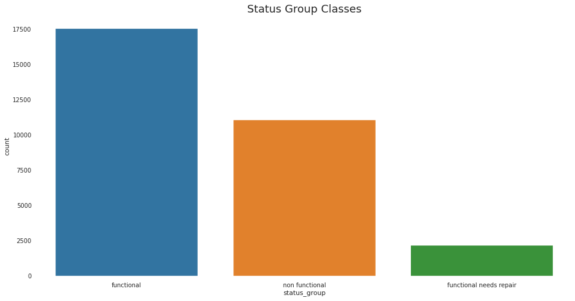

```python
# converting 0s in poulation and construction_year to nan to ease droping

df_inscope = df_inscope.replace({'funder':0, 'installer':0, 'population':0, 'construction_year':0}, np.nan)
df_inscope = df_inscope.replace({'funder':'0', 'installer':'0'}, np.nan)


# droping nans
df_inscope.dropna(inplace=True)

# QA checks after droping nans
# data points counts of each class
print (df_inscope['status_group'].value_counts())
print ("\n \n")

# data points percentage of each class
print (df_inscope['status_group'].value_counts()/len(df_inscope['status_group']))
# bar plot of classes
plt.figure(figsize=(16,8))
plt.title("Status Group Classes",fontsize=18)
sns.countplot(df_inscope['status_group'])
```

> class balance wasn't affected by the drop.nan- that is a good initial sign

```python
df_inscope.info()
```

```
<class 'pandas.core.frame.DataFrame'>
Int64Index: 30791 entries, 69572 to 26348
Data columns (total 20 columns):
 #   Column                 Non-Null Count  Dtype
---  ------                 --------------  -----
 0   amount_tsh             30791 non-null  float64
 1   date_recorded          30791 non-null  datetime64[ns]
 2   funder                 30791 non-null  object
 3   gps_height             30791 non-null  float64
 4   installer              30791 non-null  object
 5   wpt_name               30791 non-null  object
 6   basin                  30791 non-null  object
 7   population             30791 non-null  float64
 8   public_meeting         30791 non-null  object
 9   scheme_management      30791 non-null  object
 10  permit                 30791 non-null  object
 11  construction_year      30791 non-null  float64
 12  extraction_type_class  30791 non-null  object
 13  management_group       30791 non-null  object
 14  payment_type           30791 non-null  object
 15  water_quality          30791 non-null  object
 16  quantity_group         30791 non-null  object
 17  source_class           30791 non-null  object
 18  waterpoint_type_group  30791 non-null  object
 19  status_group           30791 non-null  object
dtypes: datetime64[ns](1), float64(4), object(15)
memory usage: 6.2+ MB
```

### Dataset cleaning/pre-processing round 6 - handling temporal features

```python
# creating new features (year, month, day, day of week)
# to enable the model from learning seasonality effects on the pump health when it was installed

df_inscope['year'] = df_inscope['date_recorded'].dt.year
df_inscope['month'] = df_inscope['date_recorded'].dt.month
df_inscope['day'] = df_inscope['date_recorded'].dt.day

# adding new categorical feature to my dataset - will need handling
df_inscope['day_of_week'] = df_inscope['date_recorded'].dt.day_name()

# droping date_recorded
df_inscope = df_inscope.drop(columns=['date_recorded'])
```

```python
#QA
display(HTML(df_inscope[:10].to_html()))
```

| index | amount_tsh | funder | gps_height | installer | wpt_name | basin | population | public_meeting | scheme_management | permit | construction_year | extraction_type_class | management_group | payment_type | water_quality | quantity_group | source_class | waterpoint_type_group | status_group | year | month | day | day_of_week |
| --- | --- | --- | --- | --- | --- | --- | --- | --- | --- | --- | --- | --- | --- | --- | --- | --- | --- | --- | --- | --- | --- | --- | --- |
| 69572 | 6000.0 | Roman | 1390.0 | Roman | none | Lake Nyasa | 109.0 | True | VWC | False | 1999.0 | gravity | user-group | annually | soft | enough | groundwater | communal standpipe | functional | 2011 | 3 | 14 | Monday |
| 34310 | 25.0 | Lottery Club | 686.0 | World vision | Kwa Mahundi | Pangani | 250.0 | True | VWC | True | 2009.0 | gravity | user-group | per bucket | soft | enough | surface | communal standpipe | functional | 2013 | 2 | 25 | Monday |
| 67743 | 0.0 | Unicef | 263.0 | UNICEF | Zahanati Ya Nanyumbu | Ruvuma / Southern Coast | 58.0 | True | VWC | True | 1986.0 | submersible | user-group | never pay | soft | dry | groundwater | communal standpipe | non functional | 2013 | 1 | 28 | Monday |
| 9944 | 20.0 | Mkinga Distric Coun | 0.0 | DWE | Tajiri | Pangani | 1.0 | True | VWC | True | 2009.0 | submersible | user-group | per bucket | salty | enough | unknown | communal standpipe | functional | 2011 | 3 | 13 | Sunday |
| 49056 | 0.0 | Private | 62.0 | Private | Mzee Hokororo | Wami / Ruvu | 345.0 | True | Private operator | False | 2011.0 | submersible | commercial | never pay | salty | enough | groundwater | other | functional | 2011 | 2 | 20 | Sunday |
| 50409 | 200.0 | Danida | 1062.0 | DANIDA | Kwa Alid Nchimbi | Lake Nyasa | 250.0 | True | WUG | False | 1987.0 | handpump | user-group | on failure | soft | insufficient | groundwater | hand pump | functional | 2013 | 2 | 18 | Monday |
| 50495 | 0.0 | Lawatefuka Water Supply | 1368.0 | Lawatefuka water sup | Kwa John Izack Mmari | Pangani | 1.0 | True | Water Board | True | 2009.0 | gravity | user-group | monthly | soft | enough | groundwater | communal standpipe | functional | 2013 | 3 | 15 | Friday |
| 61848 | 0.0 | Rudep | 1645.0 | DWE | Kwa Juvenal Ching'Ombe | Lake Tanganyika | 200.0 | True | VWC | False | 1991.0 | handpump | user-group | never pay | soft | enough | groundwater | hand pump | functional | 2011 | 8 | 4 | Thursday |
| 48451 | 500.0 | Unicef | 1703.0 | DWE | Kwa John Mtenzi | Rufiji | 35.0 | True | WUA | True | 1978.0 | gravity | user-group | monthly | soft | dry | surface | communal standpipe | non functional | 2011 | 7 | 4 | Monday |
| 58155 | 0.0 | Unicef | 1656.0 | DWE | Kwa Rose Chaula | Rufiji | 50.0 | True | WUA | True | 1978.0 | gravity | user-group | on failure | soft | dry | surface | communal standpipe | non functional | 2011 | 9 | 4 | Sunday |

### Dataset cleaning/pre-processing round 7 - handling categorical features

**Handling categorical features schemes (nominal features):**

- One-hot Encoding Scheme
- Dummy Coding Scheme
- Effect Coding Scheme
- Bin-counting Scheme
- Feature Hashing Scheme

```python
# separate categorical features in a new dataframe
cat_features = df_inscope.select_dtypes(exclude=[np.number]).columns.tolist()
num_features = df_inscope.select_dtypes(include=[np.number]).columns.tolist()



# QA
assert (len(num_features) + len(cat_features)) == df_inscope.shape[1]

# remove Y (status_group)
cat_features.remove('status_group')

print (len(cat_features) )
print (cat_features )
```

```
15
['funder', 'installer', 'wpt_name', 'basin', 'public_meeting', 'scheme_management', 'permit', 'extraction_type_class', 'management_group', 'payment_type', 'water_quality', 'quantity_group', 'source_class', 'waterpoint_type_group', 'day_of_week']
```

> lets reduce as much arity of the features as we can to reduce OHE diminsinality

```python
for cat_feature in cat_features:
    print (cat_feature)
    print (df_inscope[cat_feature].value_counts()[:10])
```

```
funder
Government Of Tanzania    5320
Danida                    1647
Unicef                     854
World Bank                 758
Norad                      715
Private Individual         691
District Council           646
Germany Republi            610
Tasaf                      486
Tcrs                       485
Name: funder, dtype: int64
installer
DWE                 9233
RWE                  904
Government           619
TCRS                 611
CES                  610
DANIDA               583
DANID                552
Community            496
District Council     474
LGA                  377
Name: installer, dtype: int64
wpt_name
none               2114
Shuleni             975
Zahanati            386
Msikitini           365
Kanisani            182
Sokoni              180
Ofisini             146
Shule Ya Msingi     122
Sekondari            84
Bombani              83
Name: wpt_name, dtype: int64
basin
Pangani                    8393
Rufiji                     4880
Wami / Ruvu                4089
```

[output cut: 76 more lines]

```
hand pump              6086
other                  2705
improved spring         306
cattle trough            49
dam                       4
Name: waterpoint_type_group, dtype: int64
day_of_week
Wednesday    4963
Tuesday      4655
Thursday     4535
Monday       4423
Friday       4354
Saturday     4044
Sunday       3817
Name: day_of_week, dtype: int64
```

```python
def reduce_arity_funder(datapoint):
    if datapoint['funder']=='Government Of Tanzania':
        return 'gov'
    elif datapoint['funder']=='Danida':
        return 'danida'
    elif datapoint['funder']=='Hesawa':
        return 'hesawa'
    elif datapoint['funder']=='Rwssp':
        return 'rwssp'
    elif datapoint['funder']=='World Bank':
        return 'world_bank'
    elif datapoint['funder']=='Kkkt':
        return 'Kkkt'
    elif datapoint['funder']=='World Vision':
        return 'World Vision'
    elif datapoint['funder']=='Unicef':
        return 'Unicef'
    elif datapoint['funder']=='Tasaf':
        return 'Tasaf'
    elif datapoint['funder']=='District Council':
        return 'District Council'
    else:
        return 'other'

def reduce_arity_installer(row):
    if row['installer']=='DWE':
        return 'dwe'
    elif row['installer']=='Government':
        return 'gov'
    elif row['installer']=='RWE':
        return 'rwe'
    elif row['installer']=='Commu':
        return 'commu'
    elif row['installer']=='DANIDA':
        return 'danida'
    elif row['installer']=='KKKT':
        return 'kkkt'
    elif row['installer']=='Hesawa':
        return 'hesawa'
    elif row['installer']=='TCRS':
        return 'tcrs'
    elif row['installer']=='Central government':
        return 'Central government'
    else:
        return 'other'

def reduce_arity_scheme_management(row):
    if row['scheme_management']=='VWC':
        return 'vwc'
    elif row['scheme_management']=='WUG':
        return 'wug'
    elif row['scheme_management']=='Water authority':
        return 'wtr_auth'
    elif row['scheme_management']=='WUA':
        return 'wua'
    elif row['scheme_management']=='Water Board':
        return 'wtr_brd'
    elif row['scheme_management']=='Parastatal':
        return 'Parastatal'
    elif row['scheme_management']=='Private operator':
        return 'pri_optr'
    elif row['scheme_management']=='SWC':
        return 'swc'
    elif row['scheme_management']=='Company':
        return 'company'
    elif row['scheme_management']=='Trust':
        return 'trust'
    else:
        return 'other'

def reduce_arity_wpt_name(row):
    if row['wpt_name']=='none':
        return 'none'
    elif row['wpt_name']=='Shuleni':
        return 'Shuleni'
    elif row['wpt_name']=='Zahanati':
        return 'Zahanati'
    elif row['wpt_name']=='Msikitini':
        return 'Msikitini'
    elif row['wpt_name']=='Kanisani':
        return 'Kanisani'
    elif row['wpt_name']=='Sokoni':
        return 'Sokoni'
    elif row['wpt_name']=='Ofisini':
        return 'Ofisini'
    elif row['wpt_name']=='Shule Ya Msingi':
        return 'Shule Ya Msingi'
    elif row['wpt_name']=='Sekondari':
        return 'Sekondari'
    elif row['wpt_name']=='Bombani':
        return 'Bombani'
    else:
        return 'other'
```

```python
# a quick implementaion of the OHE without high cardenality mitigation  - except for funder
df_categorical = df_inscope[cat_features]

# reducing funder arity to mitigate the curse of diminsinality
df_categorical['funder'] = df_categorical.apply(lambda datapoint: reduce_arity_funder(datapoint), axis=1)

# reducing installer arity to mitigate the curse of diminsinality
df_categorical['installer'] = df_categorical.apply(lambda datapoint: reduce_arity_installer(datapoint), axis=1)

# reducing scheme arity to mitigate the curse of diminsinality
df_categorical['scheme_management'] = df_categorical.apply(lambda datapoint: reduce_arity_scheme_management(datapoint), axis=1)

# reducing wpt_name arity to mitigate the curse of diminsinality
df_categorical['wpt_name'] = df_categorical.apply(lambda datapoint: reduce_arity_wpt_name(datapoint), axis=1)
```

```python
# transforming the features
df_categorical = pd.get_dummies(df_categorical, dummy_na=False)
df_categorical.shape
```

```
(30791, 101)
```

```python
#QA
display(HTML(df_categorical[:10].to_html()))
```

| index | funder_District Council | funder_Kkkt | funder_Tasaf | funder_Unicef | funder_World Vision | funder_danida | funder_gov | funder_hesawa | funder_other | funder_rwssp | funder_world_bank | installer_danida | installer_dwe | installer_gov | installer_hesawa | installer_kkkt | installer_other | installer_rwe | installer_tcrs | wpt_name_Bombani | wpt_name_Kanisani | wpt_name_Msikitini | wpt_name_Ofisini | wpt_name_Sekondari | wpt_name_Shule Ya Msingi | wpt_name_Shuleni | wpt_name_Sokoni | wpt_name_Zahanati | wpt_name_none | … |
| --- | --- | --- | --- | --- | --- | --- | --- | --- | --- | --- | --- | --- | --- | --- | --- | --- | --- | --- | --- | --- | --- | --- | --- | --- | --- | --- | --- | --- | --- | --- |
| 69572 | 0 | 0 | 0 | 0 | 0 | 0 | 0 | 0 | 1 | 0 | 0 | 0 | 0 | 0 | 0 | 0 | 1 | 0 | 0 | 0 | 0 | 0 | 0 | 0 | 0 | 0 | 0 | 0 | 1 | … |
| 34310 | 0 | 0 | 0 | 0 | 0 | 0 | 0 | 0 | 1 | 0 | 0 | 0 | 0 | 0 | 0 | 0 | 1 | 0 | 0 | 0 | 0 | 0 | 0 | 0 | 0 | 0 | 0 | 0 | 0 | … |
| 67743 | 0 | 0 | 0 | 1 | 0 | 0 | 0 | 0 | 0 | 0 | 0 | 0 | 0 | 0 | 0 | 0 | 1 | 0 | 0 | 0 | 0 | 0 | 0 | 0 | 0 | 0 | 0 | 0 | 0 | … |
| 9944 | 0 | 0 | 0 | 0 | 0 | 0 | 0 | 0 | 1 | 0 | 0 | 0 | 1 | 0 | 0 | 0 | 0 | 0 | 0 | 0 | 0 | 0 | 0 | 0 | 0 | 0 | 0 | 0 | 0 | … |
| 49056 | 0 | 0 | 0 | 0 | 0 | 0 | 0 | 0 | 1 | 0 | 0 | 0 | 0 | 0 | 0 | 0 | 1 | 0 | 0 | 0 | 0 | 0 | 0 | 0 | 0 | 0 | 0 | 0 | 0 | … |
| 50409 | 0 | 0 | 0 | 0 | 0 | 1 | 0 | 0 | 0 | 0 | 0 | 1 | 0 | 0 | 0 | 0 | 0 | 0 | 0 | 0 | 0 | 0 | 0 | 0 | 0 | 0 | 0 | 0 | 0 | … |
| 50495 | 0 | 0 | 0 | 0 | 0 | 0 | 0 | 0 | 1 | 0 | 0 | 0 | 0 | 0 | 0 | 0 | 1 | 0 | 0 | 0 | 0 | 0 | 0 | 0 | 0 | 0 | 0 | 0 | 0 | … |
| 61848 | 0 | 0 | 0 | 0 | 0 | 0 | 0 | 0 | 1 | 0 | 0 | 0 | 1 | 0 | 0 | 0 | 0 | 0 | 0 | 0 | 0 | 0 | 0 | 0 | 0 | 0 | 0 | 0 | 0 | … |
| 48451 | 0 | 0 | 0 | 1 | 0 | 0 | 0 | 0 | 0 | 0 | 0 | 0 | 1 | 0 | 0 | 0 | 0 | 0 | 0 | 0 | 0 | 0 | 0 | 0 | 0 | 0 | 0 | 0 | 0 | … |
| 58155 | 0 | 0 | 0 | 1 | 0 | 0 | 0 | 0 | 0 | 0 | 0 | 0 | 1 | 0 | 0 | 0 | 0 | 0 | 0 | 0 | 0 | 0 | 0 | 0 | 0 | 0 | 0 | 0 | 0 | … |

### Dataset cleaning/pre-processing round 8 - handling unblanced classes

why unbalanced classes is a problem? If you have a breast cancer dataset, 10 malignant and 90 benign. If the model predicted benign for all the test set it will still be considered an accurate model. Imbalanced data leads to a biased prediction towards the majority class..

**Handling Imbalanced classes/data:**

- Under-sampling ( random balanced subset) -> you lose information
- Over-sampling (adding dummy duplicate minority samples) -> duplication isn't a good solution
- ROSE (hypered between up and down)
- SMOTE (syntatic minority over sampling technique) -> this is my choice!

current class class is functional 57%, then non functional 35.9% and need repair with I choose to apply SMOTE on train dataset as this will syntatically create data points for the miniority class without losing any of the sampled data information.

```
functional                 17562
non functional             11081
functional needs repair     2148
Name: status_group, dtype: int64



functional                 0.570361
non functional             0.359878
functional needs repair    0.069761
Name: status_group, dtype: float64
```

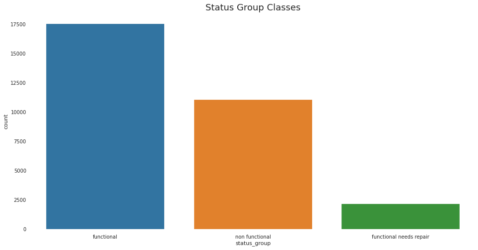

```python
# currunt class balance
print (df_inscope['status_group'].value_counts())
print ("\n \n")

# data points percentage of each class
print (df_inscope['status_group'].value_counts()/len(df_inscope['status_group']))
# bar plot of classes
plt.figure(figsize=(16,8))
plt.title("Status Group Classes",fontsize=18)
sns.countplot(df_inscope['status_group'])
```

### Dataset cleaning/pre-processing - saving final dataset

```python
# extracting y
y = df_inscope['status_group'].astype('category')


# droping categorical features -
X = df_inscope.drop(columns=cat_features)

# droping status_group label -
X = X.drop(columns=['status_group'])


# added encoded categorical features
X = X.join(df_categorical, on='index', how = 'inner')


#QA
print (y)
X.info()

display(HTML(X[:10].to_html()))
```

```
index
69572        functional
34310        functional
67743    non functional
9944         functional
49056        functional
              ...
44885    non functional
11164    non functional
60739        functional
27263        functional
26348        functional
Name: status_group, Length: 30791, dtype: category
Categories (3, object): ['functional', 'functional needs repair', 'non functional']
<class 'pandas.core.frame.DataFrame'>
Int64Index: 30791 entries, 69572 to 26348
Columns: 108 entries, amount_tsh to day_of_week_Wednesday
dtypes: float64(4), int64(3), uint8(101)
memory usage: 4.8 MB
```

| index | amount_tsh | gps_height | population | construction_year | year | month | day | funder_District Council | funder_Kkkt | funder_Tasaf | funder_Unicef | funder_World Vision | funder_danida | funder_gov | funder_hesawa | funder_other | funder_rwssp | funder_world_bank | installer_danida | installer_dwe | installer_gov | installer_hesawa | installer_kkkt | installer_other | installer_rwe | installer_tcrs | wpt_name_Bombani | wpt_name_Kanisani | wpt_name_Msikitini | … |
| --- | --- | --- | --- | --- | --- | --- | --- | --- | --- | --- | --- | --- | --- | --- | --- | --- | --- | --- | --- | --- | --- | --- | --- | --- | --- | --- | --- | --- | --- | --- |
| 69572 | 6000.0 | 1390.0 | 109.0 | 1999.0 | 2011 | 3 | 14 | 0 | 0 | 0 | 0 | 0 | 0 | 0 | 0 | 1 | 0 | 0 | 0 | 0 | 0 | 0 | 0 | 1 | 0 | 0 | 0 | 0 | 0 | … |
| 34310 | 25.0 | 686.0 | 250.0 | 2009.0 | 2013 | 2 | 25 | 0 | 0 | 0 | 0 | 0 | 0 | 0 | 0 | 1 | 0 | 0 | 0 | 0 | 0 | 0 | 0 | 1 | 0 | 0 | 0 | 0 | 0 | … |
| 67743 | 0.0 | 263.0 | 58.0 | 1986.0 | 2013 | 1 | 28 | 0 | 0 | 0 | 1 | 0 | 0 | 0 | 0 | 0 | 0 | 0 | 0 | 0 | 0 | 0 | 0 | 1 | 0 | 0 | 0 | 0 | 0 | … |
| 9944 | 20.0 | 0.0 | 1.0 | 2009.0 | 2011 | 3 | 13 | 0 | 0 | 0 | 0 | 0 | 0 | 0 | 0 | 1 | 0 | 0 | 0 | 1 | 0 | 0 | 0 | 0 | 0 | 0 | 0 | 0 | 0 | … |
| 49056 | 0.0 | 62.0 | 345.0 | 2011.0 | 2011 | 2 | 20 | 0 | 0 | 0 | 0 | 0 | 0 | 0 | 0 | 1 | 0 | 0 | 0 | 0 | 0 | 0 | 0 | 1 | 0 | 0 | 0 | 0 | 0 | … |
| 50409 | 200.0 | 1062.0 | 250.0 | 1987.0 | 2013 | 2 | 18 | 0 | 0 | 0 | 0 | 0 | 1 | 0 | 0 | 0 | 0 | 0 | 1 | 0 | 0 | 0 | 0 | 0 | 0 | 0 | 0 | 0 | 0 | … |
| 50495 | 0.0 | 1368.0 | 1.0 | 2009.0 | 2013 | 3 | 15 | 0 | 0 | 0 | 0 | 0 | 0 | 0 | 0 | 1 | 0 | 0 | 0 | 0 | 0 | 0 | 0 | 1 | 0 | 0 | 0 | 0 | 0 | … |
| 61848 | 0.0 | 1645.0 | 200.0 | 1991.0 | 2011 | 8 | 4 | 0 | 0 | 0 | 0 | 0 | 0 | 0 | 0 | 1 | 0 | 0 | 0 | 1 | 0 | 0 | 0 | 0 | 0 | 0 | 0 | 0 | 0 | … |
| 48451 | 500.0 | 1703.0 | 35.0 | 1978.0 | 2011 | 7 | 4 | 0 | 0 | 0 | 1 | 0 | 0 | 0 | 0 | 0 | 0 | 0 | 0 | 1 | 0 | 0 | 0 | 0 | 0 | 0 | 0 | 0 | 0 | … |
| 58155 | 0.0 | 1656.0 | 50.0 | 1978.0 | 2011 | 9 | 4 | 0 | 0 | 0 | 1 | 0 | 0 | 0 | 0 | 0 | 0 | 0 | 0 | 1 | 0 | 0 | 0 | 0 | 0 | 0 | 0 | 0 | 0 | … |

```python
# save modeling ready features and labels sets
y.to_csv('../data/y.csv', encoding='utf-8')
X.to_csv('../data/X.csv', encoding='utf-8')
```